# Risk Factor Analysis

## Outcome Variable

**Outcome Variable:** swasted

## Predictor Variables

**Intervention Variable:** mage

**Adjustment Set:**

- arm
- meducyrs
- feducyrs
- hhwealth_quart
- W_mhtcm
- W_nrooms
- impfloor
- impsan
- delta_meducyrs
- delta_feducyrs
- delta_hhwealth_quart
- delta_W_mhtcm
- delta_W_nrooms
- delta_impfloor
- delta_impsan

## Stratifying Variables

The analysis was stratified on these variable(s):

- agecat
- studyid
- country

## Data Summary

| agecat | studyid | country | mage | swasted | n_cell | n |
| --- | --- | --- | --- | --- | --- | --- |
| Birth | ki0047075b-MAL-ED | BANGLADESH | <25 | 0 | 107 | 241 |
| Birth | ki0047075b-MAL-ED | BANGLADESH | <25 | 1 | 2 | 241 |
| Birth | ki0047075b-MAL-ED | BANGLADESH | [25-30) | 0 | 85 | 241 |
| Birth | ki0047075b-MAL-ED | BANGLADESH | [25-30) | 1 | 4 | 241 |
| Birth | ki0047075b-MAL-ED | BANGLADESH | >=30 | 0 | 41 | 241 |
| Birth | ki0047075b-MAL-ED | BANGLADESH | >=30 | 1 | 2 | 241 |
| Birth | ki0047075b-MAL-ED | BRAZIL | <25 | 0 | 94 | 183 |
| Birth | ki0047075b-MAL-ED | BRAZIL | <25 | 1 | 0 | 183 |
| Birth | ki0047075b-MAL-ED | BRAZIL | [25-30) | 0 | 50 | 183 |
| Birth | ki0047075b-MAL-ED | BRAZIL | [25-30) | 1 | 0 | 183 |
| Birth | ki0047075b-MAL-ED | BRAZIL | >=30 | 0 | 39 | 183 |
| Birth | ki0047075b-MAL-ED | BRAZIL | >=30 | 1 | 0 | 183 |
| Birth | ki0047075b-MAL-ED | INDIA | <25 | 0 | 114 | 202 |
| Birth | ki0047075b-MAL-ED | INDIA | <25 | 1 | 6 | 202 |
| Birth | ki0047075b-MAL-ED | INDIA | [25-30) | 0 | 66 | 202 |
| Birth | ki0047075b-MAL-ED | INDIA | [25-30) | 1 | 1 | 202 |
| Birth | ki0047075b-MAL-ED | INDIA | >=30 | 0 | 15 | 202 |
| Birth | ki0047075b-MAL-ED | INDIA | >=30 | 1 | 0 | 202 |
| Birth | ki0047075b-MAL-ED | NEPAL | <25 | 0 | 42 | 168 |
| Birth | ki0047075b-MAL-ED | NEPAL | <25 | 1 | 1 | 168 |
| Birth | ki0047075b-MAL-ED | NEPAL | [25-30) | 0 | 87 | 168 |
| Birth | ki0047075b-MAL-ED | NEPAL | [25-30) | 1 | 3 | 168 |
| Birth | ki0047075b-MAL-ED | NEPAL | >=30 | 0 | 35 | 168 |
| Birth | ki0047075b-MAL-ED | NEPAL | >=30 | 1 | 0 | 168 |
| Birth | ki0047075b-MAL-ED | PERU | <25 | 0 | 155 | 279 |
| Birth | ki0047075b-MAL-ED | PERU | <25 | 1 | 0 | 279 |
| Birth | ki0047075b-MAL-ED | PERU | [25-30) | 0 | 60 | 279 |
| Birth | ki0047075b-MAL-ED | PERU | [25-30) | 1 | 0 | 279 |
| Birth | ki0047075b-MAL-ED | PERU | >=30 | 0 | 64 | 279 |
| Birth | ki0047075b-MAL-ED | PERU | >=30 | 1 | 0 | 279 |

[output cut: 378 more lines]

The following strata were considered:

- agecat: 24 months, studyid: ki0047075b-MAL-ED, country: BANGLADESH
- agecat: 24 months, studyid: ki0047075b-MAL-ED, country: BRAZIL
- agecat: 24 months, studyid: ki0047075b-MAL-ED, country: INDIA
- agecat: 24 months, studyid: ki0047075b-MAL-ED, country: NEPAL
- agecat: 24 months, studyid: ki0047075b-MAL-ED, country: PERU
- agecat: 24 months, studyid: ki0047075b-MAL-ED, country: SOUTH AFRICA
- agecat: 24 months, studyid: ki0047075b-MAL-ED, country: TANZANIA, UNITED REPUBLIC OF
- agecat: 24 months, studyid: ki1000108-CMC-V-BCS-2002, country: INDIA
- agecat: 24 months, studyid: ki1000108-IRC, country: INDIA
- agecat: 24 months, studyid: ki1017093-NIH-Birth, country: BANGLADESH
- agecat: 24 months, studyid: ki1017093b-PROVIDE, country: BANGLADESH
- agecat: 24 months, studyid: ki1017093c-NIH-Crypto, country: BANGLADESH
- agecat: 24 months, studyid: ki1066203-TanzaniaChild2, country: TANZANIA, UNITED REPUBLIC OF
- agecat: 24 months, studyid: ki1101329-Keneba, country: GAMBIA
- agecat: 24 months, studyid: ki1113344-GMS-Nepal, country: NEPAL
- agecat: 24 months, studyid: ki1119695-PROBIT, country: BELARUS
- agecat: 24 months, studyid: ki1126311-ZVITAMBO, country: ZIMBABWE
- agecat: 24 months, studyid: ki1135781-COHORTS, country: GUATEMALA
- agecat: 24 months, studyid: ki1135781-COHORTS, country: INDIA
- agecat: 24 months, studyid: ki1135781-COHORTS, country: PHILIPPINES
- agecat: 24 months, studyid: ki1148112-LCNI-5, country: MALAWI
- agecat: 24 months, studyid: kiGH5241-JiVitA-3, country: BANGLADESH
- agecat: 6 months, studyid: ki0047075b-MAL-ED, country: BANGLADESH
- agecat: 6 months, studyid: ki0047075b-MAL-ED, country: BRAZIL
- agecat: 6 months, studyid: ki0047075b-MAL-ED, country: INDIA
- agecat: 6 months, studyid: ki0047075b-MAL-ED, country: NEPAL
- agecat: 6 months, studyid: ki0047075b-MAL-ED, country: PERU
- agecat: 6 months, studyid: ki0047075b-MAL-ED, country: SOUTH AFRICA
- agecat: 6 months, studyid: ki0047075b-MAL-ED, country: TANZANIA, UNITED REPUBLIC OF
- agecat: 6 months, studyid: ki1000108-CMC-V-BCS-2002, country: INDIA
- agecat: 6 months, studyid: ki1000108-IRC, country: INDIA
- agecat: 6 months, studyid: ki1000109-EE, country: PAKISTAN
- agecat: 6 months, studyid: ki1000304b-SAS-CompFeed, country: INDIA
- agecat: 6 months, studyid: ki1000304b-SAS-FoodSuppl, country: INDIA
- agecat: 6 months, studyid: ki1017093-NIH-Birth, country: BANGLADESH
- agecat: 6 months, studyid: ki1017093b-PROVIDE, country: BANGLADESH
- agecat: 6 months, studyid: ki1017093c-NIH-Crypto, country: BANGLADESH
- agecat: 6 months, studyid: ki1066203-TanzaniaChild2, country: TANZANIA, UNITED REPUBLIC OF
- agecat: 6 months, studyid: ki1101329-Keneba, country: GAMBIA
- agecat: 6 months, studyid: ki1112895-Guatemala BSC, country: GUATEMALA
- agecat: 6 months, studyid: ki1113344-GMS-Nepal, country: NEPAL
- agecat: 6 months, studyid: ki1119695-PROBIT, country: BELARUS
- agecat: 6 months, studyid: ki1126311-ZVITAMBO, country: ZIMBABWE
- agecat: 6 months, studyid: ki1135781-COHORTS, country: GUATEMALA
- agecat: 6 months, studyid: ki1135781-COHORTS, country: INDIA
- agecat: 6 months, studyid: ki1135781-COHORTS, country: PHILIPPINES
- agecat: 6 months, studyid: ki1148112-LCNI-5, country: MALAWI
- agecat: 6 months, studyid: kiGH5241-JiVitA-3, country: BANGLADESH
- agecat: Birth, studyid: ki0047075b-MAL-ED, country: BANGLADESH
- agecat: Birth, studyid: ki0047075b-MAL-ED, country: BRAZIL
- agecat: Birth, studyid: ki0047075b-MAL-ED, country: INDIA
- agecat: Birth, studyid: ki0047075b-MAL-ED, country: NEPAL
- agecat: Birth, studyid: ki0047075b-MAL-ED, country: PERU
- agecat: Birth, studyid: ki0047075b-MAL-ED, country: SOUTH AFRICA
- agecat: Birth, studyid: ki0047075b-MAL-ED, country: TANZANIA, UNITED REPUBLIC OF
- agecat: Birth, studyid: ki1000108-CMC-V-BCS-2002, country: INDIA
- agecat: Birth, studyid: ki1000108-IRC, country: INDIA
- agecat: Birth, studyid: ki1000109-EE, country: PAKISTAN
- agecat: Birth, studyid: ki1000304b-SAS-CompFeed, country: INDIA
- agecat: Birth, studyid: ki1017093-NIH-Birth, country: BANGLADESH
- agecat: Birth, studyid: ki1017093c-NIH-Crypto, country: BANGLADESH
- agecat: Birth, studyid: ki1101329-Keneba, country: GAMBIA
- agecat: Birth, studyid: ki1119695-PROBIT, country: BELARUS
- agecat: Birth, studyid: ki1126311-ZVITAMBO, country: ZIMBABWE
- agecat: Birth, studyid: ki1135781-COHORTS, country: GUATEMALA
- agecat: Birth, studyid: ki1135781-COHORTS, country: INDIA
- agecat: Birth, studyid: ki1135781-COHORTS, country: PHILIPPINES
- agecat: Birth, studyid: kiGH5241-JiVitA-3, country: BANGLADESH

### Dropped Strata

Some strata were dropped due to rare outcomes:

- agecat: Birth, studyid: ki0047075b-MAL-ED, country: BANGLADESH
- agecat: Birth, studyid: ki0047075b-MAL-ED, country: BRAZIL
- agecat: Birth, studyid: ki0047075b-MAL-ED, country: INDIA
- agecat: Birth, studyid: ki0047075b-MAL-ED, country: NEPAL
- agecat: Birth, studyid: ki0047075b-MAL-ED, country: PERU
- agecat: Birth, studyid: ki0047075b-MAL-ED, country: SOUTH AFRICA
- agecat: Birth, studyid: ki0047075b-MAL-ED, country: TANZANIA, UNITED REPUBLIC OF
- agecat: Birth, studyid: ki1000108-CMC-V-BCS-2002, country: INDIA
- agecat: Birth, studyid: ki1000109-EE, country: PAKISTAN
- agecat: Birth, studyid: ki1000304b-SAS-CompFeed, country: INDIA
- agecat: Birth, studyid: ki1017093-NIH-Birth, country: BANGLADESH
- agecat: Birth, studyid: ki1017093c-NIH-Crypto, country: BANGLADESH
- agecat: Birth, studyid: ki1101329-Keneba, country: GAMBIA
- agecat: 6 months, studyid: ki0047075b-MAL-ED, country: BANGLADESH
- agecat: 6 months, studyid: ki0047075b-MAL-ED, country: BRAZIL
- agecat: 6 months, studyid: ki0047075b-MAL-ED, country: INDIA
- agecat: 6 months, studyid: ki0047075b-MAL-ED, country: NEPAL
- agecat: 6 months, studyid: ki0047075b-MAL-ED, country: PERU
- agecat: 6 months, studyid: ki0047075b-MAL-ED, country: SOUTH AFRICA
- agecat: 6 months, studyid: ki0047075b-MAL-ED, country: TANZANIA, UNITED REPUBLIC OF
- agecat: 6 months, studyid: ki1000108-CMC-V-BCS-2002, country: INDIA
- agecat: 6 months, studyid: ki1000108-IRC, country: INDIA
- agecat: 6 months, studyid: ki1000109-EE, country: PAKISTAN
- agecat: 6 months, studyid: ki1017093-NIH-Birth, country: BANGLADESH
- agecat: 6 months, studyid: ki1017093b-PROVIDE, country: BANGLADESH
- agecat: 6 months, studyid: ki1017093c-NIH-Crypto, country: BANGLADESH
- agecat: 6 months, studyid: ki1066203-TanzaniaChild2, country: TANZANIA, UNITED REPUBLIC OF
- agecat: 6 months, studyid: ki1112895-Guatemala BSC, country: GUATEMALA
- agecat: 6 months, studyid: ki1113344-GMS-Nepal, country: NEPAL
- agecat: 6 months, studyid: ki1119695-PROBIT, country: BELARUS
- agecat: 6 months, studyid: ki1135781-COHORTS, country: GUATEMALA
- agecat: 6 months, studyid: ki1148112-LCNI-5, country: MALAWI
- agecat: 24 months, studyid: ki0047075b-MAL-ED, country: BANGLADESH
- agecat: 24 months, studyid: ki0047075b-MAL-ED, country: BRAZIL
- agecat: 24 months, studyid: ki0047075b-MAL-ED, country: INDIA
- agecat: 24 months, studyid: ki0047075b-MAL-ED, country: NEPAL
- agecat: 24 months, studyid: ki0047075b-MAL-ED, country: PERU
- agecat: 24 months, studyid: ki0047075b-MAL-ED, country: SOUTH AFRICA
- agecat: 24 months, studyid: ki0047075b-MAL-ED, country: TANZANIA, UNITED REPUBLIC OF
- agecat: 24 months, studyid: ki1000108-CMC-V-BCS-2002, country: INDIA
- agecat: 24 months, studyid: ki1000108-IRC, country: INDIA
- agecat: 24 months, studyid: ki1017093-NIH-Birth, country: BANGLADESH
- agecat: 24 months, studyid: ki1017093b-PROVIDE, country: BANGLADESH
- agecat: 24 months, studyid: ki1017093c-NIH-Crypto, country: BANGLADESH
- agecat: 24 months, studyid: ki1066203-TanzaniaChild2, country: TANZANIA, UNITED REPUBLIC OF
- agecat: 24 months, studyid: ki1119695-PROBIT, country: BELARUS
- agecat: 24 months, studyid: ki1135781-COHORTS, country: GUATEMALA
- agecat: 24 months, studyid: ki1148112-LCNI-5, country: MALAWI

## Methods Detail

We’re interested in the causal parameters $E[Y_a]$ for all values of $a \in \mathcal{A}$. These parameters represent the mean outcome if, possibly contrary to fact, we intervened to set all units to have $A=a$. Under the randomization and positivity assumptions, these are identified by the statistical parameters $\psi_a=E_W[E_{Y|A,W}(Y|A=a,W)]$. In addition, we’re interested in the mean of $Y$, $E[Y]$ under no intervention (the observed mean). We will estimate these parameters by using SuperLearner to fit the relevant likelihood factors – $E_{Y|A,W}(Y|A=a,W)$ and $p(A=a|W)$, and then updating our likelihood fit using a joint TMLE.

For unadjusted analyses ($W=\{\}$), initial likelihoods were estimated using Lrnr_glm to estimate the simple $E(Y|A)$ and Lrnr_mean to estimate $p(A)$. For adjusted analyses, a small library containing Lrnr_glmnet, Lrnr_xgboost, and Lrnr_mean was used.

Having estimated these parameters, we will then use the delta method to estimate relative risks and attributable risks relative to a prespecified baseline level of $A$.

# Results Detail

## Results Plots

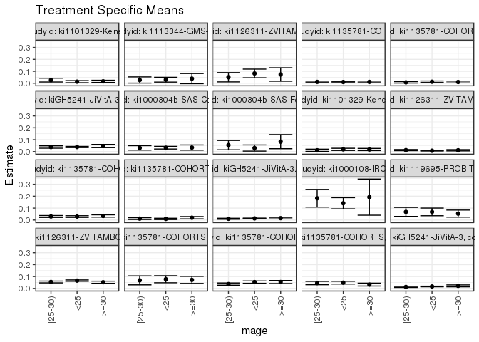

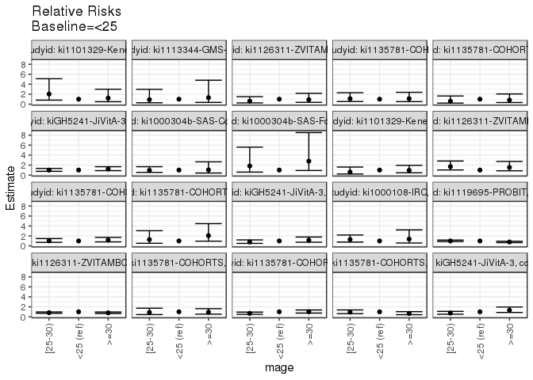

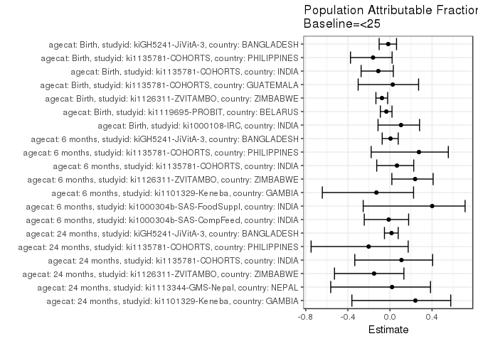

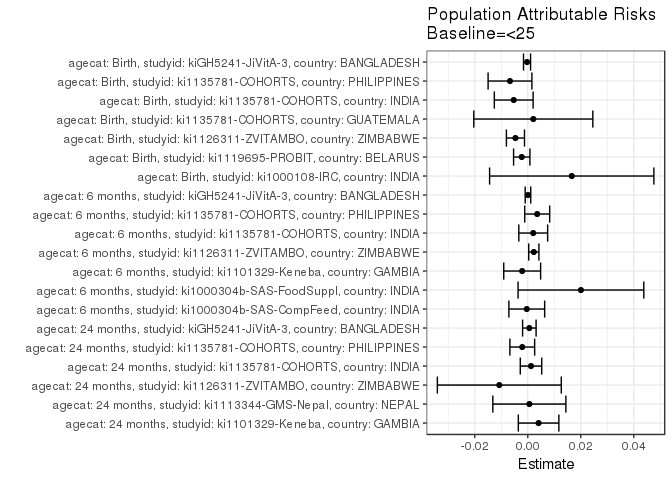

## Results Table

### Parameter: TSM

| agecat | studyid | country | intervention_level | baseline_level | estimate | ci_lower | ci_upper |
| --- | --- | --- | --- | --- | --- | --- | --- |
| Birth | ki1000108-IRC | INDIA | <25 | NA | 0.1408451 | 0.0940609 | 0.1876292 |
| Birth | ki1000108-IRC | INDIA | [25-30) | NA | 0.1826923 | 0.1083188 | 0.2570658 |
| Birth | ki1000108-IRC | INDIA | >=30 | NA | 0.1923077 | 0.0405968 | 0.3440186 |
| Birth | ki1119695-PROBIT | BELARUS | <25 | NA | 0.0681671 | 0.0360638 | 0.1002704 |
| Birth | ki1119695-PROBIT | BELARUS | [25-30) | NA | 0.0682165 | 0.0303909 | 0.1060421 |
| Birth | ki1119695-PROBIT | BELARUS | >=30 | NA | 0.0538255 | 0.0241494 | 0.0835016 |
| Birth | ki1126311-ZVITAMBO | ZIMBABWE | <25 | NA | 0.0656714 | 0.0600980 | 0.0712449 |
| Birth | ki1126311-ZVITAMBO | ZIMBABWE | [25-30) | NA | 0.0542300 | 0.0465384 | 0.0619215 |
| Birth | ki1126311-ZVITAMBO | ZIMBABWE | >=30 | NA | 0.0519002 | 0.0428513 | 0.0609491 |
| Birth | ki1135781-COHORTS | GUATEMALA | <25 | NA | 0.0772676 | 0.0475997 | 0.1069354 |
| Birth | ki1135781-COHORTS | GUATEMALA | [25-30) | NA | 0.0680351 | 0.0302138 | 0.1058564 |
| Birth | ki1135781-COHORTS | GUATEMALA | >=30 | NA | 0.0716824 | 0.0419753 | 0.1013895 |
| Birth | ki1135781-COHORTS | INDIA | <25 | NA | 0.0531972 | 0.0432470 | 0.0631474 |
| Birth | ki1135781-COHORTS | INDIA | [25-30) | NA | 0.0363797 | 0.0270453 | 0.0457142 |
| Birth | ki1135781-COHORTS | INDIA | >=30 | NA | 0.0538871 | 0.0410537 | 0.0667206 |
| Birth | ki1135781-COHORTS | PHILIPPINES | <25 | NA | 0.0484398 | 0.0368454 | 0.0600341 |
| Birth | ki1135781-COHORTS | PHILIPPINES | [25-30) | NA | 0.0450708 | 0.0310553 | 0.0590863 |
| Birth | ki1135781-COHORTS | PHILIPPINES | >=30 | NA | 0.0322183 | 0.0202466 | 0.0441900 |
| Birth | kiGH5241-JiVitA-3 | BANGLADESH | <25 | NA | 0.0164467 | 0.0137907 | 0.0191027 |
| Birth | kiGH5241-JiVitA-3 | BANGLADESH | [25-30) | NA | 0.0123415 | 0.0079921 | 0.0166909 |
| Birth | kiGH5241-JiVitA-3 | BANGLADESH | >=30 | NA | 0.0214898 | 0.0134410 | 0.0295386 |
| 6 months | ki1000304b-SAS-CompFeed | INDIA | <25 | NA | 0.0326087 | 0.0216042 | 0.0436132 |
| 6 months | ki1000304b-SAS-CompFeed | INDIA | [25-30) | NA | 0.0307263 | 0.0119739 | 0.0494786 |
| 6 months | ki1000304b-SAS-CompFeed | INDIA | >=30 | NA | 0.0337838 | 0.0117744 | 0.0557931 |
| 6 months | ki1000304b-SAS-FoodSuppl | INDIA | <25 | NA | 0.0299401 | 0.0040587 | 0.0558215 |
| 6 months | ki1000304b-SAS-FoodSuppl | INDIA | [25-30) | NA | 0.0542636 | 0.0151196 | 0.0934075 |
| 6 months | ki1000304b-SAS-FoodSuppl | INDIA | >=30 | NA | 0.0833333 | 0.0241505 | 0.1425162 |
| 6 months | ki1101329-Keneba | GAMBIA | <25 | NA | 0.0184502 | 0.0091976 | 0.0277028 |
| 6 months | ki1101329-Keneba | GAMBIA | [25-30) | NA | 0.0108225 | 0.0013855 | 0.0202595 |
| 6 months | ki1101329-Keneba | GAMBIA | >=30 | NA | 0.0173913 | 0.0083587 | 0.0264239 |
| 6 months | ki1126311-ZVITAMBO | ZIMBABWE | <25 | NA | 0.0072880 | 0.0048232 | 0.0097529 |
| 6 months | ki1126311-ZVITAMBO | ZIMBABWE | [25-30) | NA | 0.0122998 | 0.0075892 | 0.0170105 |
| 6 months | ki1126311-ZVITAMBO | ZIMBABWE | >=30 | NA | 0.0110739 | 0.0058056 | 0.0163423 |
| 6 months | ki1135781-COHORTS | INDIA | <25 | NA | 0.0289741 | 0.0219196 | 0.0360286 |
| 6 months | ki1135781-COHORTS | INDIA | [25-30) | NA | 0.0296316 | 0.0214740 | 0.0377893 |
| 6 months | ki1135781-COHORTS | INDIA | >=30 | NA | 0.0340097 | 0.0241499 | 0.0438695 |
| 6 months | ki1135781-COHORTS | PHILIPPINES | <25 | NA | 0.0093697 | 0.0038576 | 0.0148817 |
| 6 months | ki1135781-COHORTS | PHILIPPINES | [25-30) | NA | 0.0118890 | 0.0041666 | 0.0196115 |
| 6 months | ki1135781-COHORTS | PHILIPPINES | >=30 | NA | 0.0193548 | 0.0096536 | 0.0290561 |
| 6 months | kiGH5241-JiVitA-3 | BANGLADESH | <25 | NA | 0.0136511 | 0.0112759 | 0.0160263 |
| 6 months | kiGH5241-JiVitA-3 | BANGLADESH | [25-30) | NA | 0.0106461 | 0.0063889 | 0.0149033 |
| 6 months | kiGH5241-JiVitA-3 | BANGLADESH | >=30 | NA | 0.0156943 | 0.0092972 | 0.0220914 |
| 24 months | ki1101329-Keneba | GAMBIA | <25 | NA | 0.0128205 | 0.0039911 | 0.0216500 |
| 24 months | ki1101329-Keneba | GAMBIA | [25-30) | NA | 0.0260417 | 0.0101081 | 0.0419753 |
| 24 months | ki1101329-Keneba | GAMBIA | >=30 | NA | 0.0155587 | 0.0064334 | 0.0246840 |
| 24 months | ki1113344-GMS-Nepal | NEPAL | <25 | NA | 0.0295203 | 0.0093481 | 0.0496925 |
| 24 months | ki1113344-GMS-Nepal | NEPAL | [25-30) | NA | 0.0268456 | 0.0008668 | 0.0528244 |
| 24 months | ki1113344-GMS-Nepal | NEPAL | >=30 | NA | 0.0384615 | -0.0042587 | 0.0811818 |
| 24 months | ki1126311-ZVITAMBO | ZIMBABWE | <25 | NA | 0.0818182 | 0.0455571 | 0.1180793 |
| 24 months | ki1126311-ZVITAMBO | ZIMBABWE | [25-30) | NA | 0.0500000 | 0.0109591 | 0.0890409 |
| 24 months | ki1126311-ZVITAMBO | ZIMBABWE | >=30 | NA | 0.0731707 | 0.0167388 | 0.1296027 |
| 24 months | ki1135781-COHORTS | INDIA | <25 | NA | 0.0099626 | 0.0049012 | 0.0150240 |
| 24 months | ki1135781-COHORTS | INDIA | [25-30) | NA | 0.0109893 | 0.0051670 | 0.0168116 |
| 24 months | ki1135781-COHORTS | INDIA | >=30 | NA | 0.0109332 | 0.0045384 | 0.0173281 |
| 24 months | ki1135781-COHORTS | PHILIPPINES | <25 | NA | 0.0122757 | 0.0056424 | 0.0189090 |
| 24 months | ki1135781-COHORTS | PHILIPPINES | [25-30) | NA | 0.0071942 | 0.0009098 | 0.0134787 |
| 24 months | ki1135781-COHORTS | PHILIPPINES | >=30 | NA | 0.0100719 | 0.0026468 | 0.0174971 |
| 24 months | kiGH5241-JiVitA-3 | BANGLADESH | <25 | NA | 0.0383932 | 0.0334593 | 0.0433270 |
| 24 months | kiGH5241-JiVitA-3 | BANGLADESH | [25-30) | NA | 0.0382750 | 0.0283168 | 0.0482331 |
| 24 months | kiGH5241-JiVitA-3 | BANGLADESH | >=30 | NA | 0.0465864 | 0.0329428 | 0.0602299 |

### Parameter: E(Y)

| agecat | studyid | country | intervention_level | baseline_level | estimate | ci_lower | ci_upper |
| --- | --- | --- | --- | --- | --- | --- | --- |
| Birth | ki1000108-IRC | INDIA | NA | NA | 0.1574344 | 0.1188345 | 0.1960344 |
| Birth | ki1119695-PROBIT | BELARUS | NA | NA | 0.0658999 | 0.0328405 | 0.0989593 |
| Birth | ki1126311-ZVITAMBO | ZIMBABWE | NA | NA | 0.0610248 | 0.0568907 | 0.0651590 |
| Birth | ki1135781-COHORTS | GUATEMALA | NA | NA | 0.0793651 | 0.0600839 | 0.0986462 |
| Birth | ki1135781-COHORTS | INDIA | NA | NA | 0.0479001 | 0.0415930 | 0.0542073 |
| Birth | ki1135781-COHORTS | PHILIPPINES | NA | NA | 0.0417385 | 0.0344572 | 0.0490198 |
| Birth | kiGH5241-JiVitA-3 | BANGLADESH | NA | NA | 0.0161763 | 0.0138129 | 0.0185396 |
| 6 months | ki1000304b-SAS-CompFeed | INDIA | NA | NA | 0.0322339 | 0.0235219 | 0.0409459 |
| 6 months | ki1000304b-SAS-FoodSuppl | INDIA | NA | NA | 0.0500000 | 0.0280580 | 0.0719420 |
| 6 months | ki1101329-Keneba | GAMBIA | NA | NA | 0.0163462 | 0.0108955 | 0.0217968 |
| 6 months | ki1126311-ZVITAMBO | ZIMBABWE | NA | NA | 0.0095769 | 0.0074751 | 0.0116787 |
| 6 months | ki1135781-COHORTS | INDIA | NA | NA | 0.0310394 | 0.0261816 | 0.0358972 |
| 6 months | ki1135781-COHORTS | PHILIPPINES | NA | NA | 0.0129342 | 0.0086762 | 0.0171922 |
| 6 months | kiGH5241-JiVitA-3 | BANGLADESH | NA | NA | 0.0137260 | 0.0116450 | 0.0158071 |
| 24 months | ki1101329-Keneba | GAMBIA | NA | NA | 0.0169096 | 0.0108057 | 0.0230135 |
| 24 months | ki1113344-GMS-Nepal | NEPAL | NA | NA | 0.0301205 | 0.0150939 | 0.0451470 |
| 24 months | ki1126311-ZVITAMBO | ZIMBABWE | NA | NA | 0.0710900 | 0.0465431 | 0.0956370 |
| 24 months | ki1135781-COHORTS | INDIA | NA | NA | 0.0111869 | 0.0077814 | 0.0145924 |
| 24 months | ki1135781-COHORTS | PHILIPPINES | NA | NA | 0.0102082 | 0.0062264 | 0.0141901 |
| 24 months | kiGH5241-JiVitA-3 | BANGLADESH | NA | NA | 0.0389906 | 0.0346643 | 0.0433169 |

### Parameter: RR

| agecat | studyid | country | intervention_level | baseline_level | estimate | ci_lower | ci_upper |
| --- | --- | --- | --- | --- | --- | --- | --- |
| Birth | ki1000108-IRC | INDIA | <25 | <25 | 1.0000000 | 1.0000000 | 1.0000000 |
| Birth | ki1000108-IRC | INDIA | [25-30) | <25 | 1.2971154 | 0.7669954 | 2.1936355 |
| Birth | ki1000108-IRC | INDIA | >=30 | <25 | 1.3653846 | 0.5801093 | 3.2136620 |
| Birth | ki1119695-PROBIT | BELARUS | <25 | <25 | 1.0000000 | 1.0000000 | 1.0000000 |
| Birth | ki1119695-PROBIT | BELARUS | [25-30) | <25 | 1.0007241 | 0.8567486 | 1.1688945 |
| Birth | ki1119695-PROBIT | BELARUS | >=30 | <25 | 0.7896106 | 0.6636371 | 0.9394966 |
| Birth | ki1126311-ZVITAMBO | ZIMBABWE | <25 | <25 | 1.0000000 | 1.0000000 | 1.0000000 |
| Birth | ki1126311-ZVITAMBO | ZIMBABWE | [25-30) | <25 | 0.8257770 | 0.7000592 | 0.9740715 |
| Birth | ki1126311-ZVITAMBO | ZIMBABWE | >=30 | <25 | 0.7903008 | 0.6511077 | 0.9592506 |
| Birth | ki1135781-COHORTS | GUATEMALA | <25 | <25 | 1.0000000 | 1.0000000 | 1.0000000 |
| Birth | ki1135781-COHORTS | GUATEMALA | [25-30) | <25 | 0.8805133 | 0.4481473 | 1.7300199 |
| Birth | ki1135781-COHORTS | GUATEMALA | >=30 | <25 | 0.9277164 | 0.5275632 | 1.6313831 |
| Birth | ki1135781-COHORTS | INDIA | <25 | <25 | 1.0000000 | 1.0000000 | 1.0000000 |
| Birth | ki1135781-COHORTS | INDIA | [25-30) | <25 | 0.6838648 | 0.4980532 | 0.9389984 |
| Birth | ki1135781-COHORTS | INDIA | >=30 | <25 | 1.0129687 | 0.7485972 | 1.3707047 |
| Birth | ki1135781-COHORTS | PHILIPPINES | <25 | <25 | 1.0000000 | 1.0000000 | 1.0000000 |
| Birth | ki1135781-COHORTS | PHILIPPINES | [25-30) | <25 | 0.9304502 | 0.6283700 | 1.3777513 |
| Birth | ki1135781-COHORTS | PHILIPPINES | >=30 | <25 | 0.6651215 | 0.4275281 | 1.0347547 |
| Birth | kiGH5241-JiVitA-3 | BANGLADESH | <25 | <25 | 1.0000000 | 1.0000000 | 1.0000000 |
| Birth | kiGH5241-JiVitA-3 | BANGLADESH | [25-30) | <25 | 0.7503924 | 0.5186701 | 1.0856394 |
| Birth | kiGH5241-JiVitA-3 | BANGLADESH | >=30 | <25 | 1.3066317 | 0.8708382 | 1.9605092 |
| 6 months | ki1000304b-SAS-CompFeed | INDIA | <25 | <25 | 1.0000000 | 1.0000000 | 1.0000000 |
| 6 months | ki1000304b-SAS-CompFeed | INDIA | [25-30) | <25 | 0.9422719 | 0.5307920 | 1.6727388 |
| 6 months | ki1000304b-SAS-CompFeed | INDIA | >=30 | <25 | 1.0360360 | 0.4060111 | 2.6436976 |
| 6 months | ki1000304b-SAS-FoodSuppl | INDIA | <25 | <25 | 1.0000000 | 1.0000000 | 1.0000000 |
| 6 months | ki1000304b-SAS-FoodSuppl | INDIA | [25-30) | <25 | 1.8124031 | 0.5878783 | 5.5875595 |
| 6 months | ki1000304b-SAS-FoodSuppl | INDIA | >=30 | <25 | 2.7833333 | 0.9092694 | 8.5199663 |
| 6 months | ki1101329-Keneba | GAMBIA | <25 | <25 | 1.0000000 | 1.0000000 | 1.0000000 |
| 6 months | ki1101329-Keneba | GAMBIA | [25-30) | <25 | 0.5865801 | 0.2145213 | 1.6039259 |
| 6 months | ki1101329-Keneba | GAMBIA | >=30 | <25 | 0.9426087 | 0.4579139 | 1.9403454 |
| 6 months | ki1126311-ZVITAMBO | ZIMBABWE | <25 | <25 | 1.0000000 | 1.0000000 | 1.0000000 |
| 6 months | ki1126311-ZVITAMBO | ZIMBABWE | [25-30) | <25 | 1.6876754 | 1.0126466 | 2.8126772 |
| 6 months | ki1126311-ZVITAMBO | ZIMBABWE | >=30 | <25 | 1.5194637 | 0.8477161 | 2.7235179 |
| 6 months | ki1135781-COHORTS | INDIA | <25 | <25 | 1.0000000 | 1.0000000 | 1.0000000 |
| 6 months | ki1135781-COHORTS | INDIA | [25-30) | <25 | 1.0226937 | 0.7084890 | 1.4762437 |
| 6 months | ki1135781-COHORTS | INDIA | >=30 | <25 | 1.1737946 | 0.8043027 | 1.7130291 |
| 6 months | ki1135781-COHORTS | PHILIPPINES | <25 | <25 | 1.0000000 | 1.0000000 | 1.0000000 |
| 6 months | ki1135781-COHORTS | PHILIPPINES | [25-30) | <25 | 1.2688844 | 0.5282361 | 3.0480075 |
| 6 months | ki1135781-COHORTS | PHILIPPINES | >=30 | <25 | 2.0656891 | 0.9537095 | 4.4741839 |
| 6 months | kiGH5241-JiVitA-3 | BANGLADESH | <25 | <25 | 1.0000000 | 1.0000000 | 1.0000000 |
| 6 months | kiGH5241-JiVitA-3 | BANGLADESH | [25-30) | <25 | 0.7798707 | 0.5053237 | 1.2035816 |
| 6 months | kiGH5241-JiVitA-3 | BANGLADESH | >=30 | <25 | 1.1496725 | 0.7404500 | 1.7850589 |
| 24 months | ki1101329-Keneba | GAMBIA | <25 | <25 | 1.0000000 | 1.0000000 | 1.0000000 |
| 24 months | ki1101329-Keneba | GAMBIA | [25-30) | <25 | 2.0312500 | 0.8084974 | 5.1032648 |
| 24 months | ki1101329-Keneba | GAMBIA | >=30 | <25 | 1.2135785 | 0.4911419 | 2.9986708 |
| 24 months | ki1113344-GMS-Nepal | NEPAL | <25 | <25 | 1.0000000 | 1.0000000 | 1.0000000 |
| 24 months | ki1113344-GMS-Nepal | NEPAL | [25-30) | <25 | 0.9093960 | 0.2781402 | 2.9733246 |
| 24 months | ki1113344-GMS-Nepal | NEPAL | >=30 | <25 | 1.3028846 | 0.3536271 | 4.8002784 |
| 24 months | ki1126311-ZVITAMBO | ZIMBABWE | <25 | <25 | 1.0000000 | 1.0000000 | 1.0000000 |
| 24 months | ki1126311-ZVITAMBO | ZIMBABWE | [25-30) | <25 | 0.6111111 | 0.2489996 | 1.4998290 |
| 24 months | ki1126311-ZVITAMBO | ZIMBABWE | >=30 | <25 | 0.8943089 | 0.3674339 | 2.1766867 |
| 24 months | ki1135781-COHORTS | INDIA | <25 | <25 | 1.0000000 | 1.0000000 | 1.0000000 |
| 24 months | ki1135781-COHORTS | INDIA | [25-30) | <25 | 1.1030556 | 0.5295611 | 2.2976228 |
| 24 months | ki1135781-COHORTS | INDIA | >=30 | <25 | 1.0974274 | 0.5058497 | 2.3808396 |
| 24 months | ki1135781-COHORTS | PHILIPPINES | <25 | <25 | 1.0000000 | 1.0000000 | 1.0000000 |
| 24 months | ki1135781-COHORTS | PHILIPPINES | [25-30) | <25 | 0.5860542 | 0.2098198 | 1.6369266 |
| 24 months | ki1135781-COHORTS | PHILIPPINES | >=30 | <25 | 0.8204759 | 0.3289310 | 2.0465716 |
| 24 months | kiGH5241-JiVitA-3 | BANGLADESH | <25 | <25 | 1.0000000 | 1.0000000 | 1.0000000 |
| 24 months | kiGH5241-JiVitA-3 | BANGLADESH | [25-30) | <25 | 0.9969215 | 0.7458975 | 1.3324251 |
| 24 months | kiGH5241-JiVitA-3 | BANGLADESH | >=30 | <25 | 1.2134027 | 0.8809283 | 1.6713575 |

### Parameter: PAR

| agecat | studyid | country | intervention_level | baseline_level | estimate | ci_lower | ci_upper |
| --- | --- | --- | --- | --- | --- | --- | --- |
| Birth | ki1000108-IRC | INDIA | <25 | NA | 0.0165893 | -0.0143996 | 0.0475783 |
| Birth | ki1119695-PROBIT | BELARUS | <25 | NA | -0.0022672 | -0.0053481 | 0.0008136 |
| Birth | ki1126311-ZVITAMBO | ZIMBABWE | <25 | NA | -0.0046466 | -0.0080603 | -0.0012329 |
| Birth | ki1135781-COHORTS | GUATEMALA | <25 | NA | 0.0020975 | -0.0203573 | 0.0245523 |
| Birth | ki1135781-COHORTS | INDIA | <25 | NA | -0.0052971 | -0.0126145 | 0.0020203 |
| Birth | ki1135781-COHORTS | PHILIPPINES | <25 | NA | -0.0067012 | -0.0149618 | 0.0015593 |
| Birth | kiGH5241-JiVitA-3 | BANGLADESH | <25 | NA | -0.0002704 | -0.0016009 | 0.0010600 |
| 6 months | ki1000304b-SAS-CompFeed | INDIA | <25 | NA | -0.0003748 | -0.0071232 | 0.0063736 |
| 6 months | ki1000304b-SAS-FoodSuppl | INDIA | <25 | NA | 0.0200599 | -0.0036580 | 0.0437777 |
| 6 months | ki1101329-Keneba | GAMBIA | <25 | NA | -0.0021040 | -0.0090608 | 0.0048527 |
| 6 months | ki1126311-ZVITAMBO | ZIMBABWE | <25 | NA | 0.0022889 | 0.0003691 | 0.0042086 |
| 6 months | ki1135781-COHORTS | INDIA | <25 | NA | 0.0020653 | -0.0033703 | 0.0075009 |
| 6 months | ki1135781-COHORTS | PHILIPPINES | <25 | NA | 0.0035645 | -0.0011419 | 0.0082710 |
| 6 months | kiGH5241-JiVitA-3 | BANGLADESH | <25 | NA | 0.0000749 | -0.0009700 | 0.0011198 |
| 24 months | ki1101329-Keneba | GAMBIA | <25 | NA | 0.0040891 | -0.0035585 | 0.0117367 |
| 24 months | ki1113344-GMS-Nepal | NEPAL | <25 | NA | 0.0006002 | -0.0131782 | 0.0143786 |
| 24 months | ki1126311-ZVITAMBO | ZIMBABWE | <25 | NA | -0.0107281 | -0.0341048 | 0.0126486 |
| 24 months | ki1135781-COHORTS | INDIA | <25 | NA | 0.0012243 | -0.0028177 | 0.0052663 |
| 24 months | ki1135781-COHORTS | PHILIPPINES | <25 | NA | -0.0020675 | -0.0067368 | 0.0026018 |
| 24 months | kiGH5241-JiVitA-3 | BANGLADESH | <25 | NA | 0.0005974 | -0.0019504 | 0.0031452 |

### Parameter: PAF

| agecat | studyid | country | intervention_level | baseline_level | estimate | ci_lower | ci_upper |
| --- | --- | --- | --- | --- | --- | --- | --- |
| Birth | ki1000108-IRC | INDIA | <25 | NA | 0.1053730 | -0.1133883 | 0.2811515 |
| Birth | ki1119695-PROBIT | BELARUS | <25 | NA | -0.0344044 | -0.0911539 | 0.0193935 |
| Birth | ki1126311-ZVITAMBO | ZIMBABWE | <25 | NA | -0.0761425 | -0.1333649 | -0.0218093 |
| Birth | ki1135781-COHORTS | GUATEMALA | <25 | NA | 0.0264286 | -0.3020424 | 0.2720350 |
| Birth | ki1135781-COHORTS | INDIA | <25 | NA | -0.1105867 | -0.2741238 | 0.0319600 |
| Birth | ki1135781-COHORTS | PHILIPPINES | <25 | NA | -0.1605525 | -0.3750503 | 0.0204852 |
| Birth | kiGH5241-JiVitA-3 | BANGLADESH | <25 | NA | -0.0167177 | -0.1025482 | 0.0624312 |
| 6 months | ki1000304b-SAS-CompFeed | INDIA | <25 | NA | -0.0116279 | -0.2442645 | 0.1775133 |
| 6 months | ki1000304b-SAS-FoodSuppl | INDIA | <25 | NA | 0.4011976 | -0.2541546 | 0.7140988 |
| 6 months | ki1101329-Keneba | GAMBIA | <25 | NA | -0.1287172 | -0.6426090 | 0.2244031 |
| 6 months | ki1126311-ZVITAMBO | ZIMBABWE | <25 | NA | 0.2389997 | 0.0179835 | 0.4102732 |
| 6 months | ki1135781-COHORTS | INDIA | <25 | NA | 0.0665379 | -0.1256554 | 0.2259162 |
| 6 months | ki1135781-COHORTS | PHILIPPINES | <25 | NA | 0.2755902 | -0.1786226 | 0.5547603 |
| 6 months | kiGH5241-JiVitA-3 | BANGLADESH | <25 | NA | 0.0054575 | -0.0737076 | 0.0787858 |
| 24 months | ki1101329-Keneba | GAMBIA | <25 | NA | 0.2418214 | -0.3617304 | 0.5778645 |
| 24 months | ki1113344-GMS-Nepal | NEPAL | <25 | NA | 0.0199262 | -0.5628535 | 0.3853905 |
| 24 months | ki1126311-ZVITAMBO | ZIMBABWE | <25 | NA | -0.1509091 | -0.5269872 | 0.1325456 |
| 24 months | ki1135781-COHORTS | INDIA | <25 | NA | 0.1094409 | -0.3342742 | 0.4055978 |
| 24 months | ki1135781-COHORTS | PHILIPPINES | <25 | NA | -0.2025307 | -0.7493157 | 0.1733453 |
| 24 months | kiGH5241-JiVitA-3 | BANGLADESH | <25 | NA | 0.0153218 | -0.0521910 | 0.0785028 |